# multi_seasonal_ts_TBATS

Bongus

2019 5 9

# 시계열의 다중계절성 & TBATS

## 시계열의 다중계절성

1. 시계열의 계절성 및 Frequncy
- R에서는 데이터가 시계열인지 아닌지 알 수 있도록 ts로 변환시키고, R이 인지할 수 있게 해준다.
- ts함수 안에는 Frequncy옵션이 있는데, Frequncy를 통해 시계열이 어떤 주기, 계절성이 있는지 설정할 수 있었다.
- 데이터에 따라 다양한 주기가 가능.
- 데이터가 일별 데이터라면 월~일 효과를 가지고 있기때문에 7일이라는 주기를 줄 수 있다.
- 또는 요일이 아닌 365일을 하나의 주기로 반복된다고 가정하다면, Frequncy를 365로 주면 된다.
2. 그러나 Frequncy를 여러개 넣어줄 수 있다. msts(multi seasonal time series)함수를 사용하면 여러개의 주기 사용 가능
- 이 데이터가 하나의 주기가 아닌 여러개의 주기를 동시에 가질 수 있을 경우를 의미.

## TBATS model(Exponential smoothing state space model with BOx-Cox transforemation, ARMA errors, Trends and Seasonal components)

1. tbats함수는
- 시계열을 Box-cox transformation으로 변환(분산을 일정하게: 안정)
- Exponential smoothing으로 Trend를 추정
- Error를 ARMA모형으로 모델링
- multi-seasonality를 Fourier series를 이용하여 추출(단일계절성적용가능)
2. ARIMA는 정상성이 가정된 상태의 분석. 정상성이 만족되지 않은 경우 차분을 통해 정상성을 만들어 준다.
3. 정상성을 만족하시키기 위해 Trend를 없애거나, 일정한 분산.
- Trend제거를 위해 Exponential MA를 사용.
- 일정한 분산을 위해 Log transformation을 사용.
4. TBATS Model은 EMA를통해 트랜드를 제거하고, Box-cox transformation 변환 방법을 통해 분산을 일정하게 만들어 준다. => 정상 시계열화
5. 2개 이상의 시계열을 적용할 수 있다. multi seasonality를 적용하기 위해 Fourier series를 사용하는데 Fourier series를 통해 2개 이상의 계절성을 구한다.

```r
library(forecast)
```

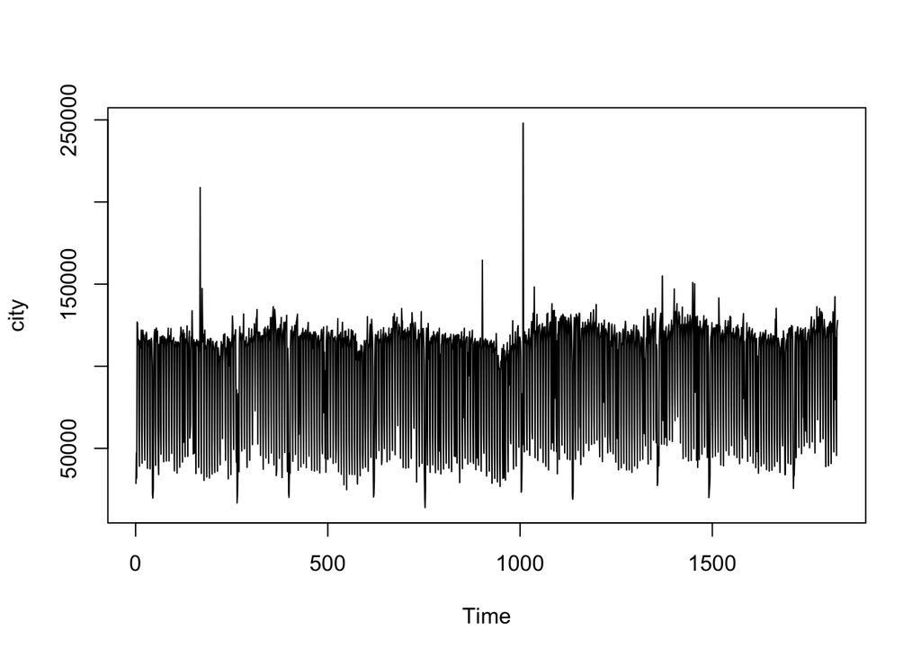

```r
library(tseries)

# Data: Seoul Metro Daily Data
metro <- read.csv('./data/seoul_metro.csv')
city <- metro$CityHall

ts.plot(city)
```

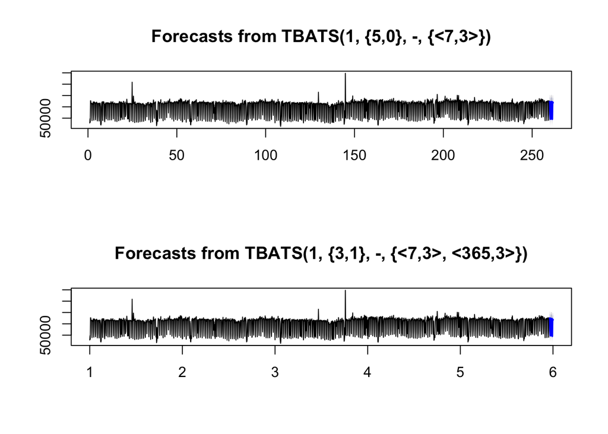

```r
# Forecasting 14 days
city_train <- city[1:1812]
city_test <- city[1813:1826]

# tbats with multi-seasonality
city_ts <- ts(city_train, frequency=7)
city_msts <- msts(city_train, seasonal.periods = c(7, 365))

# tbats는 시간이 좀 걸린다.
tbats_ts <- tbats(city_ts)
tbats_msts <- tbats(city_msts)

fcst_ts <- forecast(tbats_ts, h=14)
fcst_msts <- forecast(tbats_msts, h=14)
par(mfrow=c(2,1))
plot(fcst_ts)
plot(fcst_msts)
```

```r
mean(100 - 100*abs(as.numeric(fcst_ts$mean) - as.numeric(city_test)) / as.numeric(city_test))
```

```
## [1] 90.61247
```

```r
mean(100 - 100*abs(as.numeric(fcst_msts$mean) - as.numeric(city_test)) / as.numeric(city_test))
```

```
## [1] 91.2062
```

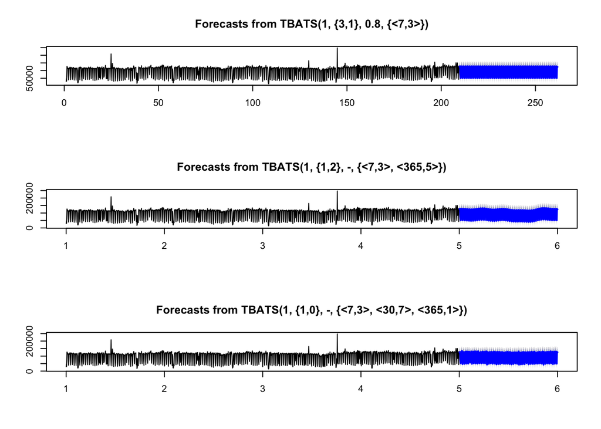

```r
par(mfrow=c(1,1))

# forecasdt 365 days
city_train2 <- city[1:1461]
city_test2 <- city[1462:1826]
city_ts2 <- ts(city_train2, frequency=7)
city_msts2 <- msts(city_train2, seasonal.periods = c(7, 365))
city_msts2_2 <- msts(city_train2, seasonal.periods = c(7, 30, 365))

tbat_ts_2 <- tbats(city_ts2)
tbat_msts_2 <- tbats(city_msts2)
tbat_msts_2_2 <- tbats(city_msts2_2)

fcst_ts_2 <- forecast(tbat_ts_2, h=365)
fcst_msts_2 <- forecast(tbat_msts_2, h=365)
fcst_msts_2_2 <- forecast(tbat_msts_2_2, h=365)

par(mfrow=c(3,1))
plot(fcst_ts_2)
plot(fcst_msts_2)
plot(fcst_msts_2_2)
```

```r
mean(100 - 100*abs(as.numeric(fcst_ts_2$mean) - as.numeric(city_test2)) / as.numeric(city_test2))
```

```
## [1] 83.506
```

```r
mean(100 - 100*abs(as.numeric(fcst_msts_2$mean) - as.numeric(city_test2)) / as.numeric(city_test2))
```

```
## [1] 85.42365
```

```r
mean(100 - 100*abs(as.numeric(fcst_msts_2_2$mean) - as.numeric(city_test2)) / as.numeric(city_test2))
```

```
## [1] 84.54537
```

```r
par(mfrow=c(1,1))
```

6. STL, HW, ARIMA Seasonality는 월별 데이터라면 1월끼리 모아서 평, 2월, 3월끼리 모아서 계산을 한다. Fourier Series는 보다 세밀하게 계절성을 계산한다.
7. Fourier Series는 주기함수를 삼각함수의 가중치로 분해한 급수이다.
- 주기가 있는 데이터를 sine, cosine을 이용해서 표현한다.
- 반복되는 seasonality를 좀 더 세밀하게 수학적으로 표현하기에 적합.
8. Fourier Series: 주기가 존재하는 시계열을 Sine, Cosine Function의 합으로 표현.
9. auto.arima에서도 Fourier Series를 적용시킬 수 있다.
- auto.arima에서도 기본은 단일계절성
- frequency가 350 이상이거나 Multi-seasonaliy를 고려할 때 Fourier Series를 이용.
- auto.arima 내부적으로 Fourier term을 추가하여 seasonality를 계산
- auto.arima 함수의 xreg 옵션에 입력하여 적용.

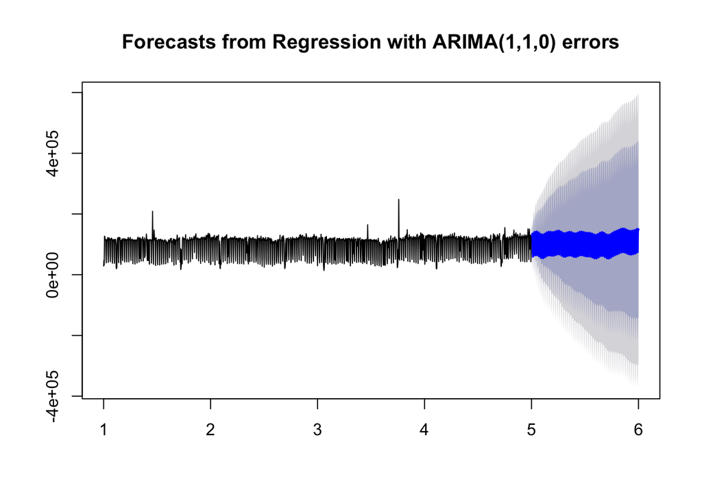

```r
city_train3 <- city[1:1461]
city_test3 <- city[1462:1826]

city_msts_3 <- msts(city_train3, seasonal.periods = c(7, 365))

fourier_arima <- fourier(city_msts_3, K=c(3, 10))
fourier_arima_reg <- fourier(city_msts_3, K=c(3, 10), h=365)
arima_msts <- auto.arima(city_msts_3, seasonal = F, xreg=fourier_arima)
fcst_msts_3 <- forecast(arima_msts, xreg=fourier_arima_reg, h=365)
plot(fcst_msts_3)
```

```r
mean(100 - 100*abs(as.numeric(fcst_msts_3$mean) - as.numeric(city_test3)) / as.numeric(city_test3))
```

```
## [1] 71.88158
```